# Actual Outbreak

Cale Basaraba

### Introduction

#### Parameters

$\beta$ = 1.4456 – Contact rate implemented alongside $\rho$

$\gamma$ = 0.167 – Recovery rate

$\mu$ = 0.0 – Base mortality rate

$\alpha$ = 0.4 – Disease mortality rate

$\phi$ = 0.0 – Infectiousness of environmental virions

$\eta$ = 0.0 – Degradation of environmental virions

$\nu$ = 0.0 – Update rate of environmental virions

$\sigma$ = 0.0 – Virion shedding rate

$\omega$ = 0.03 – Inter-patch movement rate

$\rho$ = 0.8526 – Contact non-linearity parameter

$\lambda$ = 0.0 – External force of infection

$\tau$-crit = 0.0 – Critical surveillance time

$I$-crit = 0.0 – Threshold for reporting

$\pi$-report = 0.0 – Reporting probability

$\pi$-detect = 0.0 – Detection probability

### Initial Run

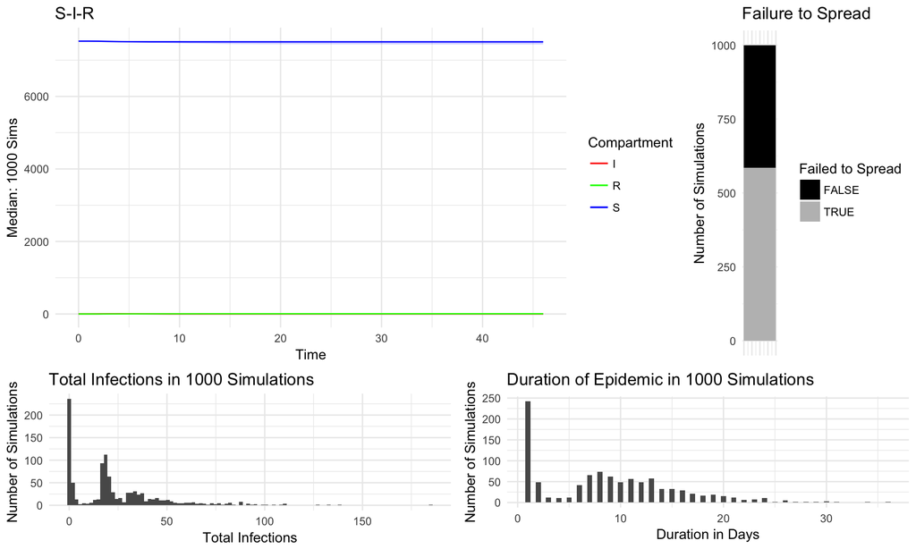

### Growth Run

Eleven percent of farms have grown in size by an order of magnititude, resulting in the doubling of total chicken population in the system. This intensification occurs in the same region.

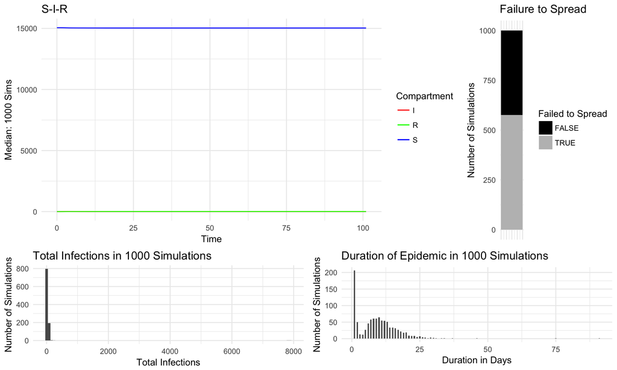